# Using Tree’s to predict Heart Disease

Joshua Welch

April 24, 2018

```r
> library(rpart)
> library(rpart.plot)
> library(maptree)
Loading required package: cluster
> # the following utility files can be found attached to the assignment
> source("https://raw.githubusercontent.com/grbruns/cst383/master/lin-regr-util.R")
> source("https://raw.githubusercontent.com/grbruns/cst383/master/class-util.R")
```

### Reading and preprocessing the data

Here we are pulling in the data and changing the column names. Then we are setting the column “output” to factor.

```r
> heart = read.table("https://raw.githubusercontent.com/grbruns/cst383/master/heart.dat", quote = "/")
> names(heart) <- c("AGE", "SEX", "CHESTPAIN", "RESTBP", "CHOL",
+                   "SUGAR", "ECG", "MAXHR", "ANGINA", "DEP", "EXERCISE", "FLUOR",
+                   "THAL", "OUTPUT")
> names(heart) = tolower(names(heart))
>
> # convert output to factor
> heart$output = factor(heart$output)
```

### Data exploration

Looking at the data there is 270 rows of data with 14 columns.

```r
> #str(heart)
> #summary(heart)
```

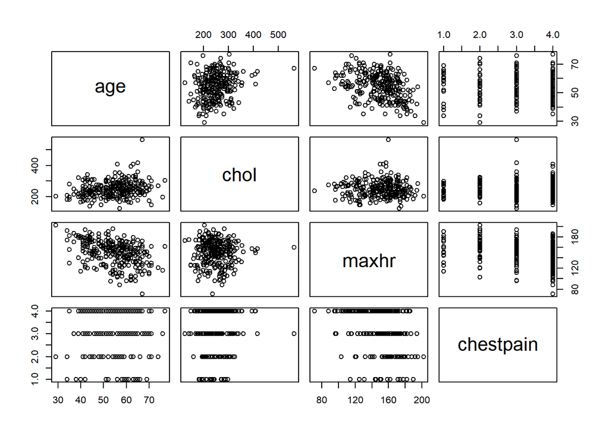

```r
> plot(heart[,c("age", "chol", "maxhr", "chestpain")])
```

Here I am looking at a scatterplot of age, cholesterol, maxhr, and chestpain to see what or if their is any correlations.

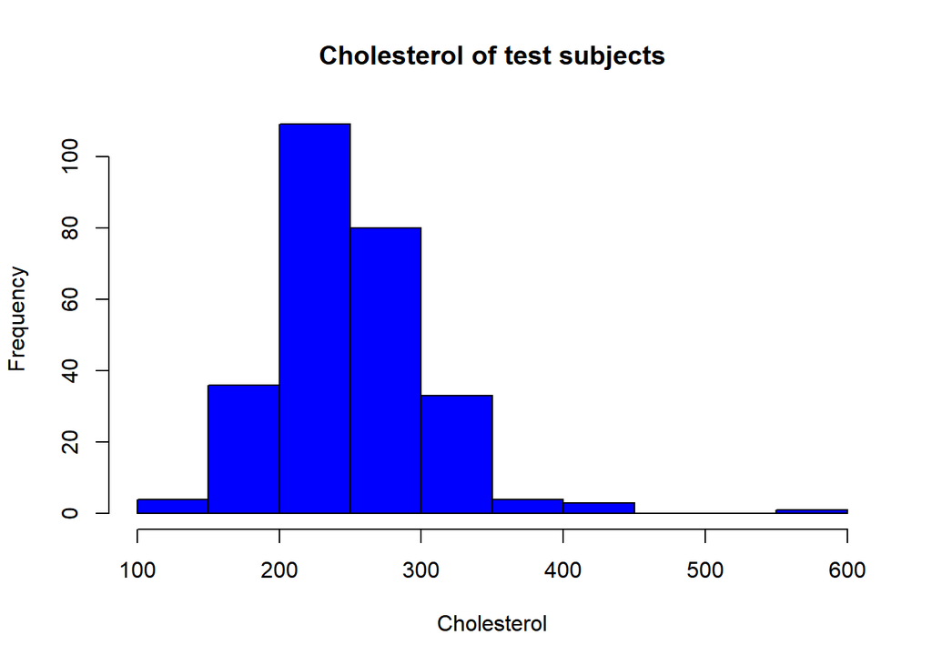

```r
> hist(heart$chol, main="Cholesterol of test subjects", xlab="Cholesterol", col="blue")
```

### Model #1

Model 1 is created simply using all of the columns, which is generraly not the best idea but gives a good idea of the data to see which columns are more useful than others. Since the data set is rather small this is easy to run, where a larger data set could be problematic.

```r
> # training and test sets
> set.seed(132)
> split = split_data(heart)
> tr_dat = split[[1]]
> te_dat = split[[2]]
```

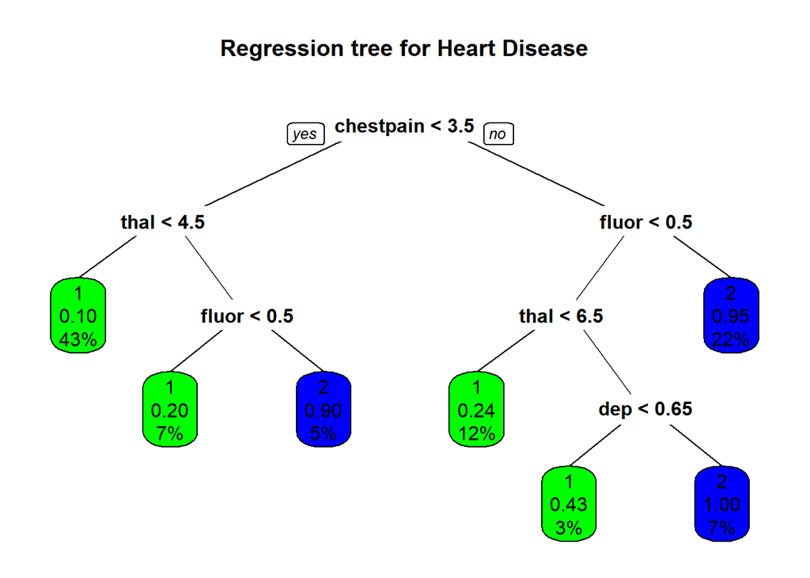

```r
> fit=rpart(output~., data=tr_dat, method="class")
> parmar=c(1,1,1,2)
> prp(fit, extra=106, varlen=-10, main="Regression tree for Heart Disease", box.col=c("green", "blue")[fit$frame$yval])
```

```r
> summary(fit)
```

```
Call:
rpart(formula = output ~ ., data = tr_dat, method = "class")
  n= 201

          CP nsplit rel error    xerror       xstd
1 0.46511628      0 1.0000000 1.0000000 0.08156459
2 0.07558140      1 0.5348837 0.6976744 0.07543775
3 0.04651163      3 0.3837209 0.5930233 0.07173552
4 0.01162791      5 0.2906977 0.4302326 0.06388903
5 0.01000000      6 0.2790698 0.4418605 0.06454894

Variable importance
chestpain      thal     fluor     maxhr    angina       dep       age
       23        19        15        12        11        10         4
   restbp       sex      chol  exercise
        2         2         2         1

Node number 1: 201 observations,    complexity param=0.4651163
  predicted class=1  expected loss=0.4278607  P(node) =1
    class counts:   115    86
   probabilities: 0.572 0.428
  left son=2 (111 obs) right son=3 (90 obs)
  Primary splits:
      chestpain < 3.5   to the left,  improve=28.24280, (0 missing)
      thal      < 4.5   to the left,  improve=27.58151, (0 missing)
      fluor     < 0.5   to the left,  improve=20.47939, (0 missing)
      maxhr     < 147.5 to the right, improve=16.93352, (0 missing)
      angina    < 0.5   to the left,  improve=16.74484, (0 missing)
  Surrogate splits:
      angina < 0.5   to the left,  agree=0.736, adj=0.411, (0 split)
      thal   < 4.5   to the left,  agree=0.701, adj=0.333, (0 split)
      maxhr  < 147.5 to the right, agree=0.687, adj=0.300, (0 split)
      fluor  < 1.5   to the left,  agree=0.622, adj=0.156, (0 split)
      dep    < 1.85  to the left,  agree=0.617, adj=0.144, (0 split)

Node number 2: 111 observations,    complexity param=0.04651163
  predicted class=1  expected loss=0.1891892  P(node) =0.5522388
    class counts:    90    21
   probabilities: 0.811 0.189
  left son=4 (86 obs) right son=5 (25 obs)
```

[output cut: 99 more lines]

```
      restbp   < 143   to the left,  improve=0.7619048, (0 missing)
  Surrogate splits:
      maxhr    < 151   to the right, agree=0.857, adj=0.571, (0 split)
      exercise < 1.5   to the left,  agree=0.762, adj=0.286, (0 split)
      angina   < 0.5   to the left,  agree=0.714, adj=0.143, (0 split)

Node number 26: 7 observations
  predicted class=1  expected loss=0.4285714  P(node) =0.03482587
    class counts:     4     3
   probabilities: 0.571 0.429

Node number 27: 14 observations
  predicted class=2  expected loss=0  P(node) =0.06965174
    class counts:     0    14
   probabilities: 0.000 1.000
```

### Classifying test data

```r
> predicted=predict(fit,te_dat, type = "class")
> actuals=te_dat$output
```

### Assessing the model

Here we loop through the data testing different training data and test data sizes.

```r
> accuracy=mean(actuals==predicted)
> accuracy
```

```
[1] 0.826087
```

```r
> conf_matrix=table(actuals, predicted)
> conf_matrix
```

```
       predicted
actuals  1  2
      1 29  6
      2  6 28
```

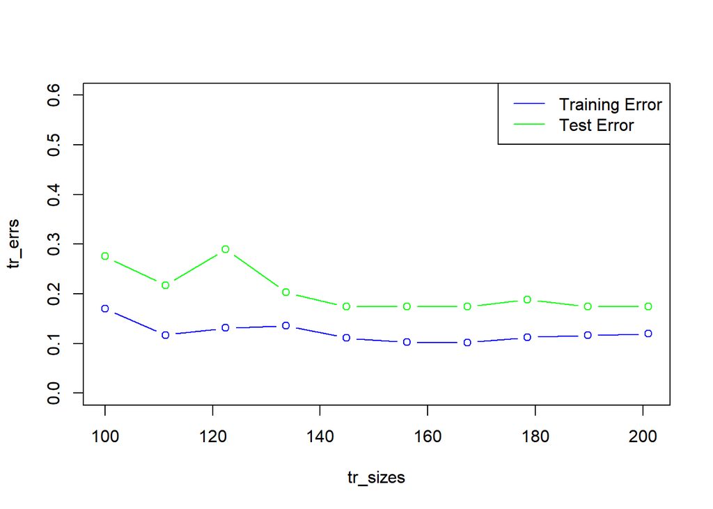

```r
> te_errs = c()
> tr_errs = c()
> te_actual = te_dat$output
> tr_sizes = seq(100, nrow(tr_dat), length.out=10)
> for (tr_size in tr_sizes) {
+   tr_dat1 = tr_dat[1:tr_size,]
+   tr_actual = tr_dat1$output
+
+   fit=rpart(output~., data=tr_dat1, method="class")
+   #training error
+
+   tr_predicted = predict(fit, tr_dat1, type="class")
+   err = mean(tr_actual != tr_predicted)
+   tr_errs = c(tr_errs, err)
+   #test error
+
+   te_predicted = predict(fit, te_dat, type="class")
+   err = mean(te_actual != te_predicted)
+   te_errs = c(te_errs, err)
+
+ }
>
> plot(tr_sizes, tr_errs,  col="blue", main="", type="b", ylim=c(0,.6))
> lines(tr_sizes,te_errs, col="green", type="b")
> legend("topright", c("Training Error","Test Error"), col= c("blue","green"), lty=1)
```

I chose to use chestpain + cholesterol + age + maxhr to create the second model.

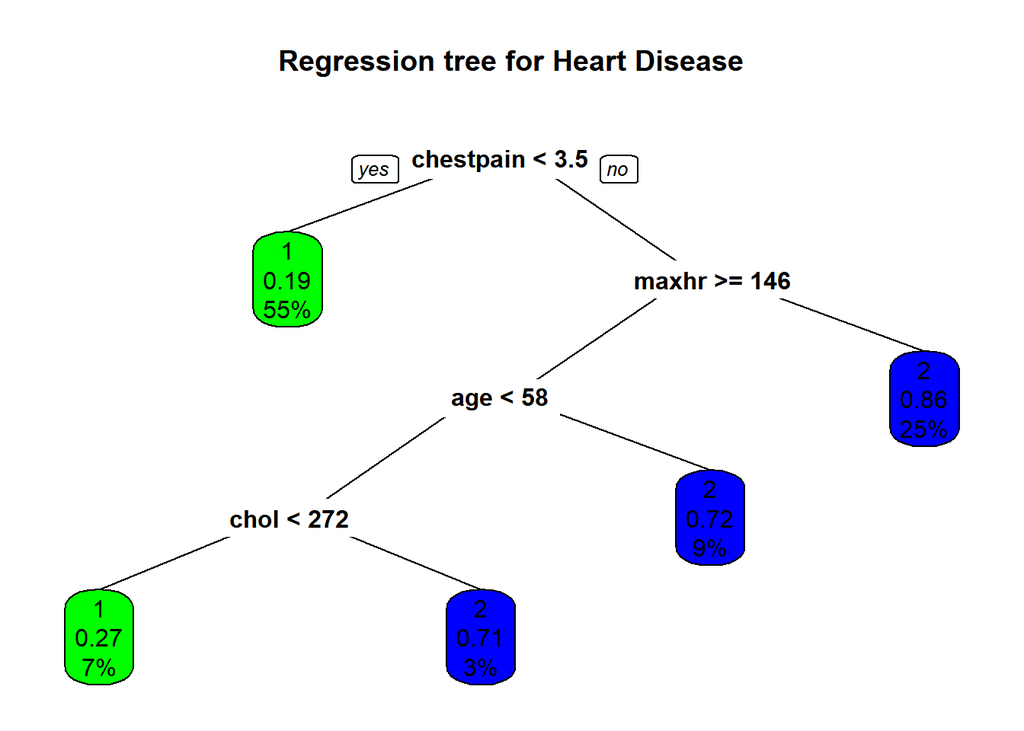

```r
> fit2=rpart(output~chestpain + chol + age + maxhr, data=tr_dat, method="class")
> parmar=c(1,1,1,2)
> prp(fit2, extra=106, varlen=-10, main="Regression tree for Heart Disease", box.col=c("green", "blue")[fit2$frame$yval])
```

```r
> #summary(fit2)
```

```r
> predicted=predict(fit2,te_dat, type = "class")
> actuals=te_dat$output
```

```r
> accuracy=mean(actuals==predicted)
> accuracy
```

```
[1] 0.7246377
```

```r
> conf_matrix=table(actuals, predicted)
> conf_matrix
```

```
       predicted
actuals  1  2
      1 28  7
      2 12 22
```

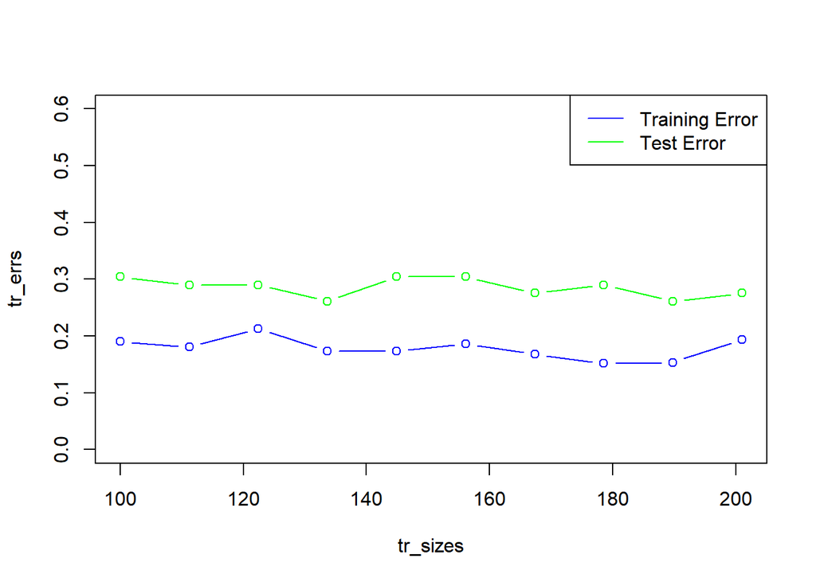

```r
> te_errs = c()
> tr_errs = c()
> te_actual = te_dat$output
> tr_sizes = seq(100, nrow(tr_dat), length.out=10)
> for (tr_size in tr_sizes) {
+   tr_dat1 = tr_dat[1:tr_size,]
+   tr_actual = tr_dat1$output
+
+   fit2=rpart(output~chestpain + chol + age + maxhr, data=tr_dat1, method="class")
+   #training error
+
+   tr_predicted = predict(fit2, tr_dat1, type="class")
+   err = mean(tr_actual != tr_predicted)
+   tr_errs = c(tr_errs, err)
+   #test error
+
+   te_predicted = predict(fit2, te_dat, type="class")
+   err = mean(te_actual != te_predicted)
+   te_errs = c(te_errs, err)
+
+ }
>
> plot(tr_sizes, tr_errs,  col="blue", main="", type="b", ylim=c(0,.6))
> lines(tr_sizes,te_errs, col="green", type="b")
> legend("topright", c("Training Error","Test Error"), col= c("blue","green"), lty=1)
```

# The models are very similar, but the second model isn’t using very good features yielding a less accurate model. To improve I would drop cholestoral and age. I would then add thal and fluor.